# Stat542: Hidden Markov Model

### The Dishonest Casino

This example is taken from Durbin et. al. (1999): A dishonest casino uses two dice, one of them is fair the other is loaded.

- The probabilities of the fair die are (1/6,…,1/6).
- The probabilities of the loaded die are (1/10,…,1/10,1/2)

The observer doesn’t know which die is actually taken (the state is hidden), but the sequence of throws (observations) can be used to infer which die (state) was used.

```r
library(HMM)
dishonestCasino()
```

```
## Plot simulated throws:
```

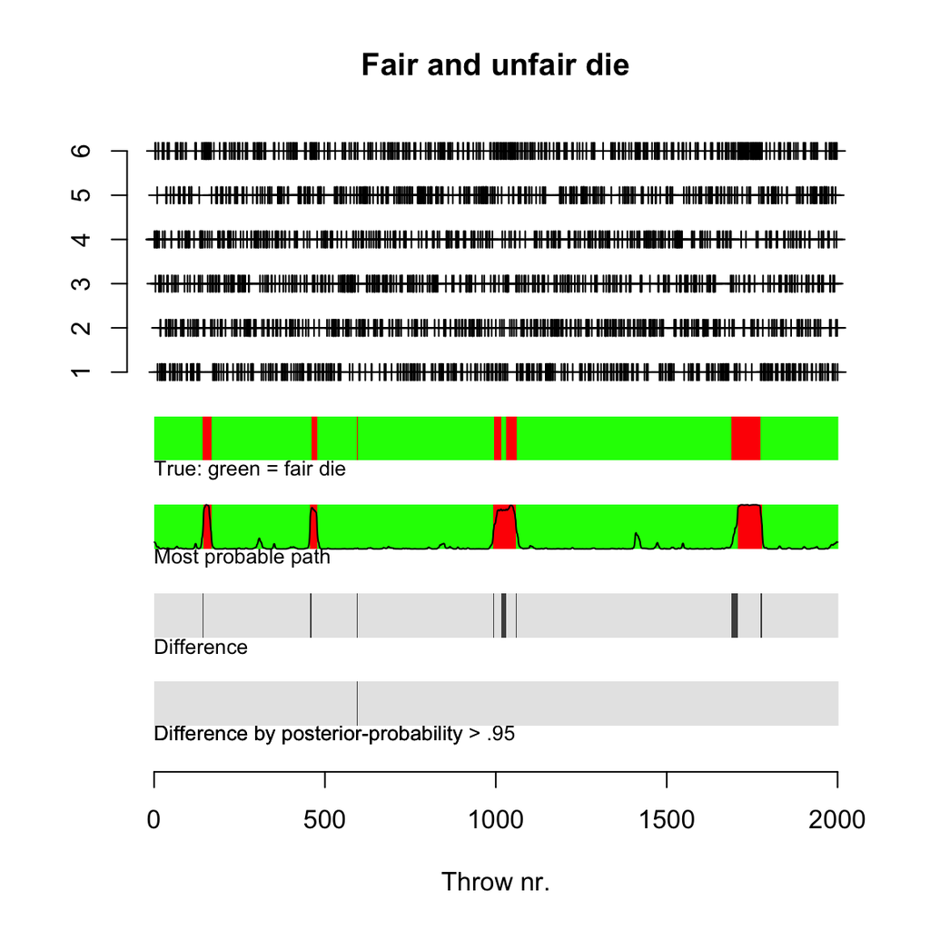

```
## Simulated, which die was used:
##
## Most probable path (viterbi):
##
## Differences:
##
## Posterior-probability:
##
## Difference with classification by posterior-probability:
##
## Difference with classification by posterior-probability > .95:
```

### A Simulated Example

Specify the following HMM.

```r
A=matrix(c(0.95,0.05,0.05,0.95),2,2);
B=matrix(c(1/3, 0.1, 1/3, 0.2, 1/3,0.7),2,3);
hmm=initHMM(c("A", "B"), c(1, 2, 3),
            startProbs=c(1/2, 1/2),
                    transProbs=A, emissionProbs=B)
print(hmm)
```

```
## $States
## [1] "A" "B"
##
## $Symbols
## [1] 1 2 3
##
## $startProbs
##   A   B
## 0.5 0.5
##
## $transProbs
##     to
## from    A    B
##    A 0.95 0.05
##    B 0.05 0.95
##
## $emissionProbs
##       symbols
## states      1      2      3
##      A 0.3333 0.3333 0.3333
##      B 0.1000 0.2000 0.7000
```

Generate n=500 obs from this HMM.

```r
n=500;
data=simHMM(hmm, n)
names(data)
```

```
## [1] "states"      "observation"
```

```r
cbind(data$states[1:5], data$observation[1:5])
```

```
##      [,1] [,2]
## [1,] "A"  "2"
## [2,] "A"  "2"
## [3,] "A"  "2"
## [4,] "A"  "3"
## [5,] "A"  "3"
```

### Fit the data with two hidden states

- Use BaumWelch (i.e., EM) algorithm to estimate the model parameters.

```r
tmphmm=initHMM(c("A", "B"), c(1, 2, 3))
myfit2 = baumWelch(hmm, data$obs)
names(myfit2)
```

```
## [1] "hmm"        "difference"
```

```r
print(myfit2$hmm)
```

```
## $States
## [1] "A" "B"
##
## $Symbols
## [1] 1 2 3
##
## $startProbs
##   A   B
## 0.5 0.5
##
## $transProbs
##     to
## from      A      B
##    A 0.8948 0.1052
##    B 0.1165 0.8835
##
## $emissionProbs
##       symbols
## states       1      2      3
##      A 0.39782 0.3099 0.2923
##      B 0.02695 0.2468 0.7262
```

- Compute the (marginal) conditional distribution of the hidden state for each observation: P(Z_i = k | X_1, …, X_n). Then classify Z_i to be the most probable state.

```r
mypost = posterior(myfit2$hmm, data$obs)
```

- Use the Viterbi algorithm to compute the most probable hidden sequence

```r
vit.out = viterbi(myfit2$hmm, data$obs)
```

- display the result

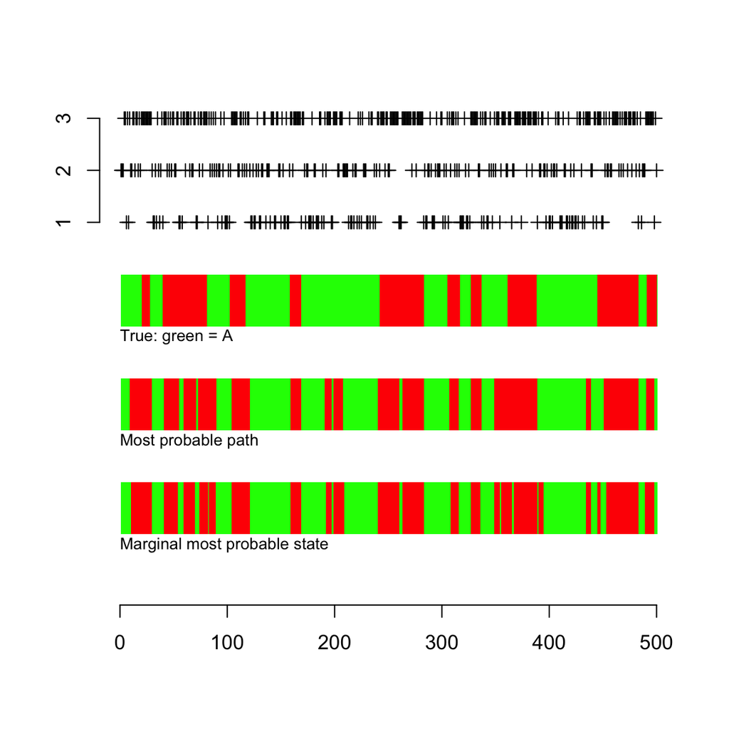

```r
# plot the data
plot(data$obs, ylim = c(-6, 3), pch = 3,
     xlab = "", ylab = "", bty = "n", yaxt = "n")
axis(2, at = 1:3)

# display true hidden states
text(0, -1.2, adj = 0, cex = 0.8, col = "black", "True: green = A")
for (i in 1:n) {
  if (data$states[i] == "A")
    rect(i, -1, i + 1, 0, col = "green", border = NA)
  else rect(i, -1, i + 1, 0, col = "red", border = NA)
}

# display the post probable path
text(0, -3.2, adj = 0, cex = 0.8, col = "black", "Most probable path")
for (i in 1:n) {
  if (vit.out[i] == "A")
    rect(i, -3, i + 1, -2, col = "green", border = NA)
  else rect(i, -3, i + 1, -2, col = "red", border = NA)
}

# display the marginal most probable state
text(0, -5.2, adj = 0, cex = 0.8, col = "black", "Marginal most probable state")
for (i in 1:n) {
  if (mypost[1,i] > 0.5)
    rect(i, -5, i + 1, -4, col = "green", border = NA)
  else rect(i, -5, i + 1, -4, col = "red", border = NA)
}
```

### Fit the data with three hidden states

The number of hidden states is a tuning parameter. We can try a range of hidden states and then use AIC/BIC to select K, the number of hidden states.

```r
tmphmm=initHMM(c("A", "B", "C"), c(1, 2, 3))
myfit3 = baumWelch(tmphmm, data$obs)
print(myfit3$hmm)
```

```
## $States
## [1] "A" "B" "C"
##
## $Symbols
## [1] 1 2 3
##
## $startProbs
##      A      B      C
## 0.3333 0.3333 0.3333
##
## $transProbs
##     to
## from      A      B      C
##    A 0.6667 0.1667 0.1667
##    B 0.1667 0.6667 0.1667
##    C 0.1667 0.1667 0.6667
##
## $emissionProbs
##       symbols
## states     1    2     3
##      A 0.222 0.28 0.498
##      B 0.222 0.28 0.498
##      C 0.222 0.28 0.498
```

Note that the likelihood of the data (integrated over all possible hidden sequences) could be computed using the `forward` command.

```r
# log-likelihood for K=2
f=forward(myfit2$hmm, data$obs) # f: 2xn
A = f[1,n]; B = f[2,n]
A + log(1 + exp(B-A))
```

```
## [1] -503.1
```

```r
# log-likelihood for K=3
f=forward(myfit3$hmm, data$obs) # f: 3xn
A = f[1,n]; B = f[-1,n]
A + log(1 + sum(exp(B-A)))
```

```
## [1] -518.9
```